# Covid19 prediction

Covid19 prediction model

```python
%matplotlib inline
%load_ext autoreload
%autoreload 2
%config InlineBackend.figure_format = 'retina'

import numpy as np
import pandas as pd
import matplotlib.pyplot as plt

import torch
```

## Load and prepare the data

Supposed, accumulated data, daily data, flight data, tested data

```python
data_path = 'train.csv'

data_train = pd.read_csv(data_path)
```

```python
display(data_train.head())
display(data_train.describe())
display(data_train.info())
```

|  | Id | County | Province_State | Country_Region | Population | Weight | Date | Target | TargetValue |
| --- | --- | --- | --- | --- | --- | --- | --- | --- | --- |
| 0 | 1 | NaN | NaN | Afghanistan | 27657145 | 0.058359 | 2020-01-23 | ConfirmedCases | 0.0 |
| 1 | 2 | NaN | NaN | Afghanistan | 27657145 | 0.583587 | 2020-01-23 | Fatalities | 0.0 |
| 2 | 3 | NaN | NaN | Afghanistan | 27657145 | 0.058359 | 2020-01-24 | ConfirmedCases | 0.0 |
| 3 | 4 | NaN | NaN | Afghanistan | 27657145 | 0.583587 | 2020-01-24 | Fatalities | 0.0 |
| 4 | 5 | NaN | NaN | Afghanistan | 27657145 | 0.058359 | 2020-01-25 | ConfirmedCases | 0.0 |

|  | Id | Population | Weight | TargetValue |
| --- | --- | --- | --- | --- |
| count | 707268.000000 | 7.072680e+05 | 707268.000000 | 707268.000000 |
| mean | 485342.412316 | 2.760837e+06 | 0.530633 | 9.640805 |
| std | 280234.533115 | 3.479154e+07 | 0.451794 | 259.611827 |
| min | 1.000000 | 8.600000e+01 | 0.047491 | -10034.000000 |
| 25% | 242633.750000 | 1.214200e+04 | 0.096825 | 0.000000 |
| 50% | 485342.500000 | 3.057300e+04 | 0.349413 | 0.000000 |
| 75% | 728051.250000 | 1.062210e+05 | 0.968251 | 0.000000 |
| max | 970684.000000 | 1.395773e+09 | 2.239186 | 36163.000000 |

```
<class 'pandas.core.frame.DataFrame'>
RangeIndex: 707268 entries, 0 to 707267
Data columns (total 9 columns):
 #   Column          Non-Null Count   Dtype
---  ------          --------------   -----
 0   Id              707268 non-null  int64
 1   County          641172 non-null  object
 2   Province_State  668304 non-null  object
 3   Country_Region  707268 non-null  object
 4   Population      707268 non-null  int64
 5   Weight          707268 non-null  float64
 6   Date            707268 non-null  object
 7   Target          707268 non-null  object
 8   TargetValue     707268 non-null  float64
dtypes: float64(2), int64(2), object(5)
memory usage: 48.6+ MB
```

```
None
```

## Checking out the data

```python
confirmed_total = data_train[data_train['Target']=='ConfirmedCases']
fatalities_total = data_train[data_train['Target']=='Fatalities']
display(confirmed_total.head())
#display(fatalities_total.head())
```

|  | Id | County | Province_State | Country_Region | Population | Weight | Date | Target | TargetValue |
| --- | --- | --- | --- | --- | --- | --- | --- | --- | --- |
| 0 | 1 | NaN | NaN | Afghanistan | 27657145 | 0.058359 | 2020-01-23 | ConfirmedCases | 0.0 |
| 2 | 3 | NaN | NaN | Afghanistan | 27657145 | 0.058359 | 2020-01-24 | ConfirmedCases | 0.0 |
| 4 | 5 | NaN | NaN | Afghanistan | 27657145 | 0.058359 | 2020-01-25 | ConfirmedCases | 0.0 |
| 6 | 7 | NaN | NaN | Afghanistan | 27657145 | 0.058359 | 2020-01-26 | ConfirmedCases | 0.0 |
| 8 | 9 | NaN | NaN | Afghanistan | 27657145 | 0.058359 | 2020-01-27 | ConfirmedCases | 0.0 |

Daily values

```python
def add_daily_confirmed(df):
    df.loc[0,'Daily Cases'] = df.loc[0,'Confirmed']
    for i in range(1,len(df)):
        df.loc[i,'Daily Cases'] = abs(df.loc[i,'Confirmed'] - df.loc[i-1,'Confirmed'])
    #Make the first row as 0 because we don't know the previous value
    df.loc[0,'Daily Cases'] = 0
    return df

def add_daily_fatalities(df):
    df.loc[0,'Daily Deaths'] = df.loc[0,'Fatalities']
    for i in range(1,len(df)):
        df.loc[i,'Daily Deaths'] = abs(df.loc[i,'Fatalities'] - df.loc[i-1,'Fatalities'])
    #Make the first row as 0 because we don't know the previous value
    df.loc[0,'Daily Deaths'] = 0
    return df
```

```python
df_world_c = confirmed_total.copy()
df_world_f = fatalities_total.copy()
df_world_c = df_world_c.groupby('Date',as_index=False)['TargetValue'].sum()
df_world_c = df_world_c.rename(columns={'TargetValue':'Confirmed'})
df_world_f = df_world_f.groupby('Date',as_index=False)['TargetValue'].sum()
df_world_f = df_world_f.rename(columns={'TargetValue':'Fatalities'})
df_world = pd.merge(df_world_c, df_world_f)

print(df_world)
```

```
           Date  Confirmed  Fatalities
0    2020-01-23      194.0         2.0
1    2020-01-24      566.0        16.0
2    2020-01-25      980.0        32.0
3    2020-01-26     1358.0        28.0
4    2020-01-27     1612.0        52.0
..          ...        ...         ...
97   2020-04-29   133704.0     13643.0
98   2020-04-30   152901.0     10888.0
99   2020-05-01   163158.0     10505.0
100  2020-05-02   149273.0      9097.0
101  2020-05-03   137528.0      6878.0

[102 rows x 3 columns]
```

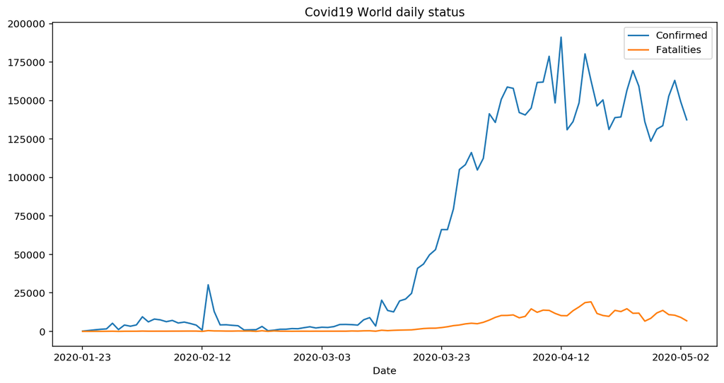

```python
df_world.plot(title ='Covid19 World daily status', x='Date', figsize=(12,6))
#df_world.plot(title ='Covid19 World daily status', y=['Daily Cases','Daily Deaths'], x='Date', figsize=(12,6))
```

## Daily status

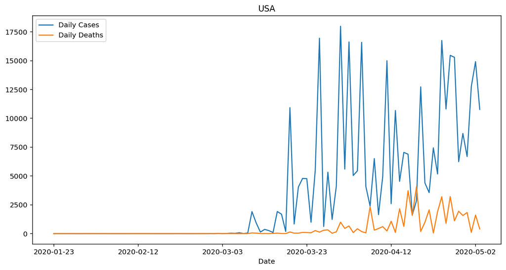

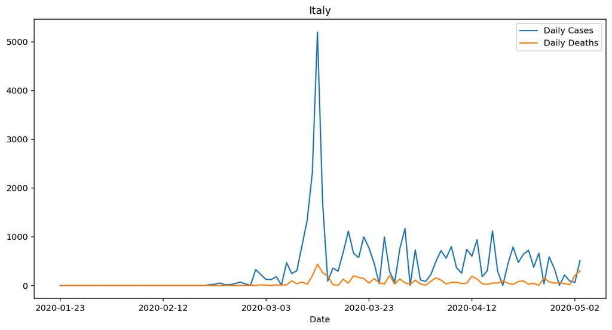

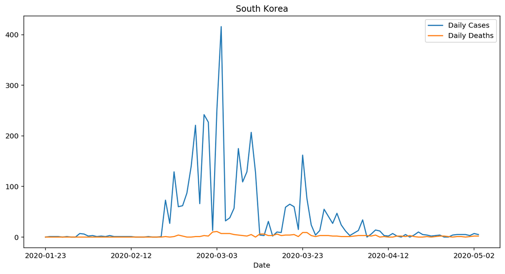

```python
# USA
df_usa_c = confirmed_total.query("Country_Region=='US'")
df_usa_c = df_usa_c.groupby('Date',as_index=False)['TargetValue'].sum()
df_usa_c = df_usa_c.rename(columns={'TargetValue':'Confirmed'})
df_usa_c = add_daily_confirmed(df_usa_c)
df_usa_f = fatalities_total.query("Country_Region=='US'")
df_usa_f = df_usa_f.groupby('Date',as_index=False)['TargetValue'].sum()
df_usa_f = df_usa_f.rename(columns={'TargetValue':'Fatalities'})
df_usa_f = add_daily_fatalities(df_usa_f)

df_usa = pd.merge(df_usa_c, df_usa_f)
df_usa.plot(title = "USA", y=['Daily Cases','Daily Deaths'], x='Date', figsize=(12,6))

#print(df_usa)

# Italy
df_italy_c = confirmed_total.query("Country_Region=='Italy'")
df_italy_c = df_italy_c.groupby('Date',as_index=False)['TargetValue'].sum()
df_italy_c = df_italy_c.rename(columns={'TargetValue':'Confirmed'})
df_italy_c = add_daily_confirmed(df_italy_c)
df_italy_f = fatalities_total.query("Country_Region=='Italy'")
df_italy_f = df_italy_f.groupby('Date',as_index=False)['TargetValue'].sum()
df_italy_f = df_italy_f.rename(columns={'TargetValue':'Fatalities'})
df_italy_f = add_daily_fatalities(df_italy_f)

df_italy = pd.merge(df_italy_c, df_italy_f)
df_italy.plot(title = "Italy", y=['Daily Cases','Daily Deaths'], x='Date', figsize=(12,6))

#print(df_italy)


#df_spain.plot(title = "Spain", y=['Daily Cases','Daily Deaths'], x='Date', figsize=(12,6))


# South Korea
df_korea_c = confirmed_total.query("Country_Region=='Korea, South'")
df_korea_c = df_korea_c.groupby('Date',as_index=False)['TargetValue'].sum()
df_korea_c = df_korea_c.rename(columns={'TargetValue':'Confirmed'})
df_korea_c = add_daily_confirmed(df_korea_c)
df_korea_f = fatalities_total.query("Country_Region=='Korea, South'")
df_korea_f = df_korea_f.groupby('Date',as_index=False)['TargetValue'].sum()
df_korea_f = df_korea_f.rename(columns={'TargetValue':'Fatalities'})
df_korea_f = add_daily_fatalities(df_korea_f)

df_korea = pd.merge(df_korea_c, df_korea_f)
df_korea.plot(title = "South Korea", y=['Daily Cases','Daily Deaths'], x='Date', figsize=(12,6))
#df_korea.plot(title = "South Korea", y=['Daily Cases','Daily Deaths'], x='Date', figsize=(12,6))
```

## Flight information for countries

Reference : https://www.radarbox.com/statistics/total

```python
data_flight = pd.read_csv('covid19_flight_countries_mod.csv')

data_flight.head()
```

|  | Date | Total Commercial | US <-> US | US <-> NON US | US <-> Europe | US <-> Latin America | US <-> Asia | US <-> China | Canada <-> Canada | Canada <-> NON Canada | ... | Italy <-> Italy | Italy <-> NON Italy | China <-> China | China <-> NON China | Brazil <-> Brazil | Brazil <-> NON Brazil | India <-> India | India <-> NON India | Iran <-> Iran | Iran <-> NON Iran |
| --- | --- | --- | --- | --- | --- | --- | --- | --- | --- | --- | --- | --- | --- | --- | --- | --- | --- | --- | --- | --- | --- |
| 0 | 2020-01-23 | 105890 | 27326 | 5321 | 799 | 2330 | 698 | 140 | 2717 | 1717 | ... | 610 | 1886 | 10840 | 3042 | 2357 | 465 | 2820 | 1212 | 87 | 189 |
| 1 | 2020-01-24 | 105132 | 26999 | 5351 | 821 | 2354 | 657 | 115 | 2627 | 1781 | ... | 651 | 2169 | 9005 | 2931 | 2335 | 460 | 2843 | 1239 | 110 | 182 |
| 2 | 2020-01-25 | 92176 | 22279 | 5511 | 864 | 2755 | 643 | 113 | 1799 | 1686 | ... | 483 | 1796 | 8900 | 2826 | 1990 | 460 | 2847 | 1225 | 104 | 177 |
| 3 | 2020-01-26 | 97283 | 22662 | 5215 | 902 | 2355 | 628 | 113 | 1803 | 1696 | ... | 572 | 2102 | 9491 | 2841 | 2033 | 463 | 2780 | 1198 | 102 | 190 |
| 4 | 2020-01-27 | 101573 | 25472 | 5084 | 831 | 2241 | 586 | 109 | 2501 | 1675 | ... | 641 | 2082 | 9296 | 2721 | 2374 | 450 | 2926 | 1131 | 84 | 173 |

5 rows × 27 columns

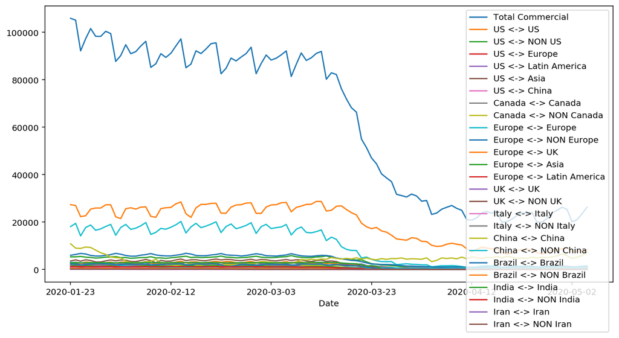

```python
data_flight.plot(x='Date', figsize=(12,6))
```

## Testd value per day

Reference : https://ourworldindata.org/grapher/full-list-covid-19-tests-per-day

```python
#full-list-covid-19-tests-per-day
data_daily_tested = pd.read_csv('full-list-covid-19-tests-per-day.csv')

data_daily_tested.head()
```

|  | Entity | Code | Date | New tests |
| --- | --- | --- | --- | --- |
| 0 | Argentina | ARG | 2020-04-09 | 1520 |
| 1 | Argentina | ARG | 2020-04-10 | 1529 |
| 2 | Argentina | ARG | 2020-04-11 | 1648 |
| 3 | Argentina | ARG | 2020-04-14 | 3047 |
| 4 | Argentina | ARG | 2020-04-15 | 1569 |

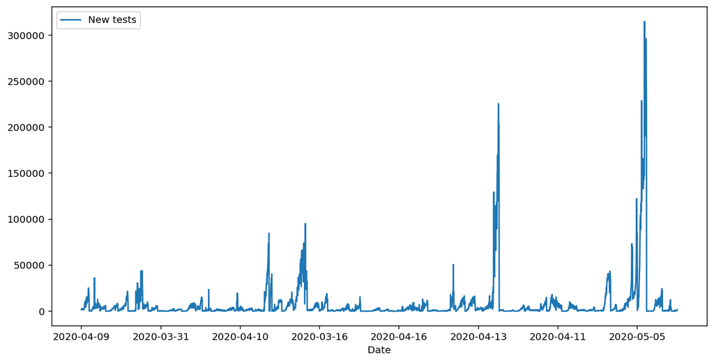

```python
data_daily_tested.plot(x='Date', figsize=(12,6))
```

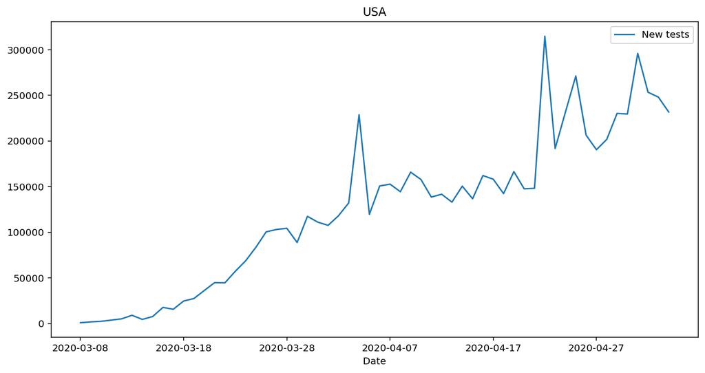

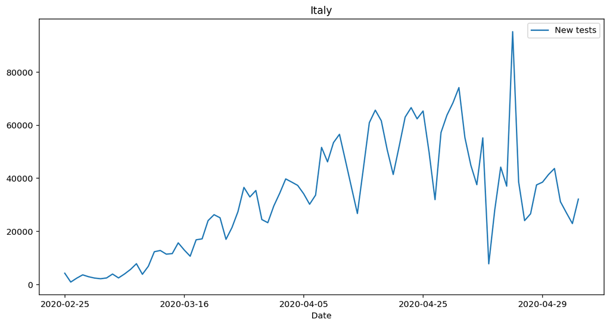

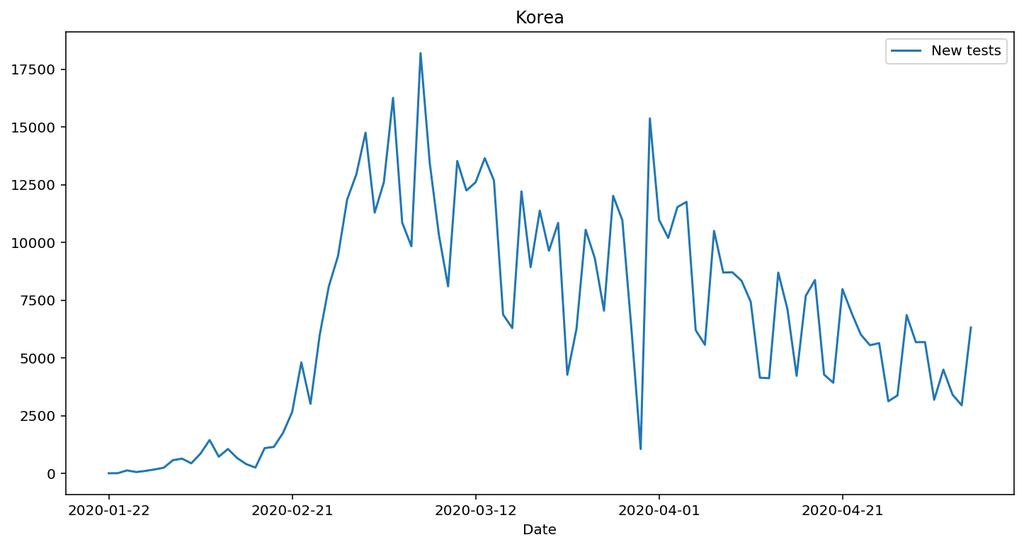

```python
df_usa_tested = data_daily_tested.query("Code=='USA'")
df_italy_tested = data_daily_tested.query("Entity=='Italy'")
df_spain_tested = data_daily_tested.query("Entity=='Spain'")
df_korea_tested = data_daily_tested.query("Entity=='South Korea'")
#df_usa_tested.head()
#df_italy_tested.head()
#df_spain_tested.head()
#df_korea_tested.head()
df_usa_tested.plot(title='USA', x='Date', figsize=(12,6))
df_italy_tested.plot(title='Italy', x='Date', figsize=(12,6))
df_korea_tested.plot(title='Korea', x='Date', figsize=(12,6))
```

```python
df_usa_merge = pd.merge(df_usa, df_usa_tested)
df_usa_merge = pd.merge(df_usa_merge, data_flight)
df_usa_merge.head()
#df_usa_merge.plot()
```

|  | Date | Confirmed | Daily Cases | Fatalities | Daily Deaths | Entity | Code | New tests | Total Commercial | US <-> US | ... | Italy <-> Italy | Italy <-> NON Italy | China <-> China | China <-> NON China | Brazil <-> Brazil | Brazil <-> NON Brazil | India <-> India | India <-> NON India | Iran <-> Iran | Iran <-> NON Iran |
| --- | --- | --- | --- | --- | --- | --- | --- | --- | --- | --- | --- | --- | --- | --- | --- | --- | --- | --- | --- | --- | --- |
| 0 | 2020-03-08 | 114.0 | 5.0 | 4.0 | 1.0 | United States | USA | 871 | 86516 | 26191 | ... | 442 | 1718 | 3076 | 533 | 1928 | 445 | 2813 | 1080 | 69 | 58 |
| 1 | 2020-03-09 | 64.0 | 50.0 | 1.0 | 3.0 | United States | USA | 1796 | 91299 | 26761 | ... | 439 | 1453 | 4257 | 553 | 2291 | 419 | 2935 | 960 | 70 | 45 |
| 2 | 2020-03-10 | 1973.0 | 1909.0 | 62.0 | 61.0 | United States | USA | 2412 | 88130 | 27429 | ... | 346 | 977 | 3998 | 705 | 2257 | 402 | 2876 | 969 | 71 | 42 |
| 3 | 2020-03-11 | 1046.0 | 927.0 | 20.0 | 42.0 | United States | USA | 3748 | 89254 | 27537 | ... | 216 | 658 | 4344 | 654 | 2248 | 393 | 3022 | 1037 | 78 | 55 |
| 4 | 2020-03-12 | 1180.0 | 134.0 | 17.0 | 3.0 | United States | USA | 5137 | 91107 | 28704 | ... | 140 | 651 | 4079 | 635 | 2254 | 443 | 2995 | 996 | 69 | 58 |

5 rows × 34 columns

```python
#USA considering case
#df_usa_data = df_usa_merge.drop(['Date', 'Entity', 'Code', 'Total Commercial', 'US <-> Latin America', 'US <-> Asia', 'US <-> China', 'Canada <-> Canada', 'Canada <-> NON Canada', 'Europe <-> Europe', 'Europe <-> NON Europe', 'Europe <-> UK', 'Europe <-> Asia', 'Europe <-> Latin America', 'UK <-> UK', 'UK <-> NON UK', 'Italy <-> Italy', 'Italy <-> NON Italy', 'China <-> China', 'China <-> NON China', 'Brazil <-> Brazil', 'Brazil <-> NON Brazil', 'India <-> India', 'India <-> NON India', 'Iran <-> Iran', 'Iran <-> NON Iran'], axis=1)
df_usa_data = df_usa_merge.drop(['Date', 'Entity', 'Code', 'US <-> Latin America', 'US <-> China', 'Canada <-> Canada', 'Canada <-> NON Canada', 'Europe <-> Europe', 'Europe <-> UK', 'Europe <-> Latin America', 'UK <-> UK', 'UK <-> NON UK', 'Italy <-> Italy', 'China <-> China', 'Brazil <-> Brazil', 'Brazil <-> NON Brazil', 'India <-> India', 'India <-> NON India', 'Iran <-> Iran'], axis=1)
df_usa_data.head()
```

|  | Confirmed | Daily Cases | Fatalities | Daily Deaths | New tests | Total Commercial | US <-> US | US <-> NON US | US <-> Europe | US <-> Asia | Europe <-> NON Europe | Europe <-> Asia | Italy <-> NON Italy | China <-> NON China | Iran <-> NON Iran |
| --- | --- | --- | --- | --- | --- | --- | --- | --- | --- | --- | --- | --- | --- | --- | --- |
| 0 | 114.0 | 5.0 | 4.0 | 1.0 | 871 | 86516 | 26191 | 5381 | 843 | 486 | 6184 | 1428 | 1718 | 533 | 58 |
| 1 | 64.0 | 50.0 | 1.0 | 3.0 | 1796 | 91299 | 26761 | 5134 | 848 | 480 | 5785 | 1284 | 1453 | 553 | 45 |
| 2 | 1973.0 | 1909.0 | 62.0 | 61.0 | 2412 | 88130 | 27429 | 4972 | 776 | 469 | 5618 | 1275 | 977 | 705 | 42 |
| 3 | 1046.0 | 927.0 | 20.0 | 42.0 | 3748 | 89254 | 27537 | 5059 | 794 | 481 | 5565 | 1314 | 658 | 654 | 55 |
| 4 | 1180.0 | 134.0 | 17.0 | 3.0 | 5137 | 91107 | 28704 | 5283 | 864 | 479 | 5779 | 1317 | 651 | 635 | 58 |

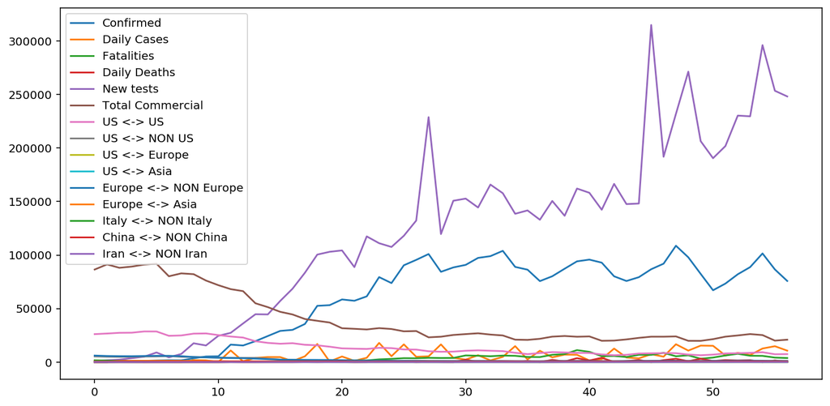

```python
df_usa_data.plot(figsize=(12,6))
```

### Scaling target variables

The scaling factors are saved so we can go backwards when we use the network for predictions.

```python
quant_features = ['Daily Cases', 'US <-> US', 'US <-> NON US','US <-> Europe', 'Confirmed', 'New tests']
# Store scalings in a dictionary so we can convert back later
scaled_features = {}
for each in quant_features:
    mean, std = df_usa_data[each].mean(), df_usa_data[each].std()
    scaled_features[each] = [mean, std]
    df_usa_data.loc[:, each] = (df_usa_data[each] - mean)/std

df_usa_data.head()
```

|  | Confirmed | Daily Cases | Fatalities | Daily Deaths | New tests | Total Commercial | US <-> US | US <-> NON US | US <-> Europe | US <-> Asia | Europe <-> NON Europe | Europe <-> Asia | Italy <-> NON Italy | China <-> NON China | Iran <-> NON Iran |
| --- | --- | --- | --- | --- | --- | --- | --- | --- | --- | --- | --- | --- | --- | --- | --- |
| 0 | -1.650976 | -1.152893 | 4.0 | 1.0 | -1.474494 | 86516 | 1.649296 | 1.991156 | 2.404940 | 486 | 6184 | 1428 | 1718 | 533 | 58 |
| 1 | -1.652337 | -1.144613 | 1.0 | 3.0 | -1.463387 | 91299 | 1.727190 | 1.840328 | 2.427282 | 480 | 5785 | 1284 | 1453 | 553 | 45 |
| 2 | -1.600358 | -0.802554 | 62.0 | 61.0 | -1.455991 | 88130 | 1.818477 | 1.741404 | 2.105567 | 469 | 5618 | 1275 | 977 | 705 | 42 |
| 3 | -1.625599 | -0.983243 | 20.0 | 42.0 | -1.439950 | 89254 | 1.833235 | 1.794530 | 2.185996 | 481 | 5565 | 1314 | 658 | 654 | 55 |
| 4 | -1.621950 | -1.129157 | 17.0 | 3.0 | -1.423273 | 91107 | 1.992713 | 1.931313 | 2.498774 | 479 | 5779 | 1317 | 651 | 635 | 58 |

### Splitting the data into training, testing, and validation sets

```python
train_size = int(len(df_usa_data)-28)
# the Public leaderboard will update based on last 28 days of predicted data.
test_data = df_usa_data[train_size:len(df_usa_data)]

# Now remove the test data from the data set
#data = df_usa_data[:-15]

# Separate the data into features and targets
target_fields = ['Daily Cases', 'New tests', 'Confirmed']
features, targets = df_usa_data.drop(target_fields, axis=1), df_usa_data[target_fields]
test_features, test_targets = test_data.drop(target_fields, axis=1), test_data[target_fields]
#train_features_cnn, train_targets_cnn = features, targets
```

Will split the data into two sets, one for training and one for validating as the network is being trained. Since this is time series data, we'll train on historical data, then try to predict on future data (the validation set).

```python
# Hold out the last 60 days or so of the remaining data as a validation set
train_size_valid = int(train_size*0.8)
train_features, train_targets = features[0:train_size_valid], targets[0:train_size_valid]
val_features, val_targets = features[train_size_valid:train_size], targets[train_size_valid:train_size]

#for mlnn
train_features_mlp, train_targets_mlp = features[0:train_size_valid], targets[0:train_size_valid]
test_features_mlp, test_targets_mlp = test_features, test_targets
val_features_mlp, val_targets_mlp = features[train_size_valid:train_size], targets[train_size_valid:train_size]

#for cnn
train_features_cnn, train_targets_cnn = features[0:train_size_valid], targets[0:train_size_valid]
val_features_cnn, val_targets_cnn = features[train_size_valid:train_size], targets[train_size_valid:train_size]

val_features.head()
```

|  | Fatalities | Daily Deaths | Total Commercial | US <-> US | US <-> NON US | US <-> Europe | US <-> Asia | Europe <-> NON Europe | Europe <-> Asia | Italy <-> NON Italy | China <-> NON China | Iran <-> NON Iran |
| --- | --- | --- | --- | --- | --- | --- | --- | --- | --- | --- | --- | --- |
| 23 | 2636.0 | 993.0 | 31804 | -0.096484 | -0.476438 | -0.526235 | 252 | 1444 | 360 | 108 | 546 | 12 |
| 24 | 3088.0 | 452.0 | 30979 | -0.135294 | -0.538113 | -0.526235 | 240 | 1369 | 355 | 135 | 564 | 35 |
| 25 | 3755.0 | 667.0 | 28809 | -0.305978 | -0.560706 | -0.503894 | 225 | 1281 | 354 | 122 | 508 | 39 |
| 26 | 3662.0 | 93.0 | 29088 | -0.322103 | -0.541166 | -0.494957 | 246 | 1241 | 334 | 118 | 545 | 38 |
| 27 | 4086.0 | 424.0 | 23215 | -0.534740 | -0.637036 | -0.579854 | 218 | 1058 | 361 | 104 | 533 | 27 |

## * Try to apply different NN way

## A. Build the network

```python
class NeuralNetwork(object):
    def __init__(self, input_nodes, hidden_nodes, output_nodes, learning_rate):
        # Set number of nodes in input, hidden and output layers.
        self.input_nodes = input_nodes
        self.hidden_nodes = hidden_nodes
        self.output_nodes = output_nodes

        # Initialize weights
        self.weights_input_to_hidden = np.random.normal(0.0, self.input_nodes**-0.5,
                                       (self.input_nodes, self.hidden_nodes))

        self.weights_hidden_to_output = np.random.normal(0.0, self.hidden_nodes**-0.5,
                                       (self.hidden_nodes, self.output_nodes))
        self.lr = learning_rate

        # Sigmoid activation function
        self.activation_function = lambda x : (1/(1+np.exp(-x)))

    def train(self, features, targets):
        n_records = features.shape[0]
        delta_weights_i_h = np.zeros(self.weights_input_to_hidden.shape)
        delta_weights_h_o = np.zeros(self.weights_hidden_to_output.shape)
        for X, y in zip(features, targets):

            final_outputs, hidden_outputs = self.forward_pass_train(X)

            delta_weights_i_h, delta_weights_h_o = self.backpropagation(final_outputs, hidden_outputs, X, y,
                                                                        delta_weights_i_h, delta_weights_h_o)
        self.update_weights(delta_weights_i_h, delta_weights_h_o, n_records)


    def forward_pass_train(self, X):

        hidden_inputs = np.dot(X, self.weights_input_to_hidden) # signals into hidden layer
        hidden_outputs = self.activation_function(hidden_inputs) # signals from hidden layer

        final_inputs = np.dot(hidden_outputs, self.weights_hidden_to_output) # signals into final output layer
        final_outputs = final_inputs # signals from final output layer


        return final_outputs, hidden_outputs

    def backpropagation(self, final_outputs, hidden_outputs, X, y, delta_weights_i_h, delta_weights_h_o):

        error = y-final_outputs # Output layer error is the difference between desired target and actual output.

        # The hidden layer's contribution to the error
        hidden_error = np.dot(self.weights_hidden_to_output, error)

        #Backpropagated error terms
        output_error_term = error * 1

        hidden_error_term = hidden_error * hidden_outputs * (1 - hidden_outputs)

        # Weight step (input to hidden)
        delta_weights_i_h += hidden_error_term * X[:,None]
        # Weight step (hidden to output)
        delta_weights_h_o += (output_error_term * hidden_outputs[:,None])
        return delta_weights_i_h, delta_weights_h_o

    def update_weights(self, delta_weights_i_h, delta_weights_h_o, n_records):

        # update hidden-to-output weights with gradient descent step
        self.weights_hidden_to_output += self.lr * delta_weights_h_o/n_records

        # update input-to-hidden weights with gradient descent step
        self.weights_input_to_hidden += self.lr * delta_weights_i_h/n_records

    def run(self, features):

        #Hidden layer
        hidden_inputs = np.dot(features, self.weights_input_to_hidden) # signals into hidden layer
        hidden_outputs = self.activation_function(hidden_inputs) # signals from hidden layer

        #Output layer
        final_inputs = np.dot(hidden_outputs, self.weights_hidden_to_output) # signals into final output layer
        final_outputs = final_inputs # signals from final output layer

        return final_outputs
```

```python
def MSE(y, Y):
    return np.mean((y-Y)**2)
```

## A-1. Hyper parameters

iterations, learning rate, hidden nodes, output nodes

```python
#Hyperparameter

iterations = 1000
learning_rate = 0.003
hidden_nodes = 25
output_nodes = 1
```

## A-2. Training for daily cases

```python
import sys

N_i = train_features.shape[1]
print(N_i)
network = NeuralNetwork(N_i, hidden_nodes, output_nodes, learning_rate)

losses = {'train':[], 'validation':[]}
for ii in range(iterations):
    # Go through a random batch of 128 records from the training data set
    batch = np.random.choice(train_features.index, size=128)
    X, y = train_features.iloc[batch].values, train_targets.iloc[batch]['Daily Cases']

    network.train(X, y)

    # Printing out the training progress
    train_loss = MSE(network.run(train_features).T, train_targets['Daily Cases'].values)
    val_loss = MSE(network.run(val_features).T, val_targets['Daily Cases'].values)
    sys.stdout.write("\rProgress: {:2.1f}".format(100 * ii/float(iterations)) \
                     + "% ... Training loss: " + str(train_loss)[:5] \
                     + " ... Validation loss: " + str(val_loss)[:5])
    sys.stdout.flush()

    losses['train'].append(train_loss)
    losses['validation'].append(val_loss)
```

```
12
Progress: 1.7% ... Training loss: 1.053 ... Validation loss: 1.725
```

```
Progress: 99.9% ... Training loss: 0.524 ... Validation loss: 3.200
```

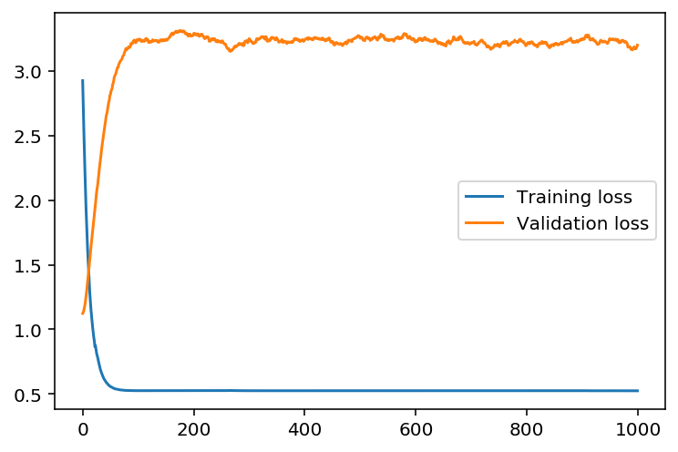

```python
plt.plot(losses['train'], label='Training loss')
plt.plot(losses['validation'], label='Validation loss')
plt.legend()
_ = plt.ylim()
```

## A-3. Check out your predictions

Here, use the test data to view how well your network is modeling the data. If something is completely wrong here, make sure each step in your network is implemented correctly.

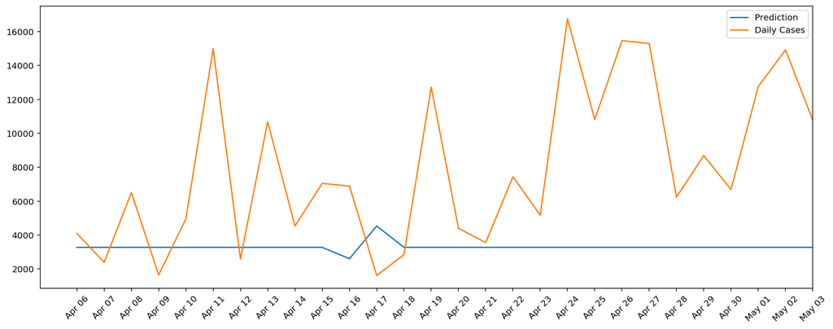

```python
fig, ax = plt.subplots(figsize=(16,6))

mean, std = scaled_features['Daily Cases']
predictions = network.run(test_features).T*std + mean
ax.plot(predictions[0], label='Prediction')
ax.plot((test_targets['Daily Cases']*std + mean).values, label='Daily Cases')
ax.set_xlim(right=len(predictions))
ax.legend()

dates = pd.to_datetime(df_usa_merge.iloc[test_data.index]['Date'])
dates = dates.apply(lambda d: d.strftime('%b %d'))
ax.set_xticks(np.arange(len(dates)))
_ = ax.set_xticklabels(dates, rotation=45)
```

## A-4. Training for confirmed

```python
#Hyperparameter

iterations = 1000
learning_rate = 0.001
hidden_nodes = 10
output_nodes = 1

N_i = train_features.shape[1]
print(N_i)
network = NeuralNetwork(N_i, hidden_nodes, output_nodes, learning_rate)

losses = {'train':[], 'validation':[]}
for ii in range(iterations):
    # Go through a random batch of 128 records from the training data set
    batch = np.random.choice(train_features.index, size=128)
    X, y = train_features.iloc[batch].values, train_targets.iloc[batch]['Confirmed']

    network.train(X, y)

    # Printing out the training progress
    train_loss = MSE(network.run(train_features).T, train_targets['Confirmed'].values)
    val_loss = MSE(network.run(val_features).T, val_targets['Confirmed'].values)
    sys.stdout.write("\rProgress: {:2.1f}".format(100 * ii/float(iterations)) \
                     + "% ... Training loss: " + str(train_loss)[:5] \
                     + " ... Validation loss: " + str(val_loss)[:5])
    sys.stdout.flush()

    losses['train'].append(train_loss)
    losses['validation'].append(val_loss)
```

```
12
Progress: 1.7% ... Training loss: 1.422 ... Validation loss: 0.460
```

```
Progress: 99.9% ... Training loss: 0.261 ... Validation loss: 2.403
```

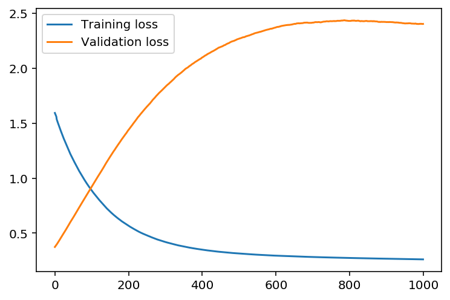

```python
plt.plot(losses['train'], label='Training loss')
plt.plot(losses['validation'], label='Validation loss')
plt.legend()
_ = plt.ylim()
```

## A-5. Check out your predictions for confirmed

[output not shown]

[figure not shown]

```python
fig, ax = plt.subplots(figsize=(16,6))

mean, std = scaled_features['Confirmed']
predictions = network(test_features).T*std + mean
ax.plot(predictions[0], label='Prediction')
ax.plot((test_targets['Confirmed']*std + mean).values, label='Confirmed')
ax.set_xlim(right=len(predictions))
ax.legend()

dates = pd.to_datetime(df_usa_merge.iloc[test_data.index]['Date'])
dates = dates.apply(lambda d: d.strftime('%b %d'))
ax.set_xticks(np.arange(len(dates)))
_ = ax.set_xticklabels(dates, rotation=45)
```

## B. multilayer perceptron model(MLP) with pytorch

```python
import torch
import torch.nn as nn
import torch.nn.functional as F
import torch.optim as optim
```

## B.1 Multi-layer model

```python
class MLPModel(nn.Module):
    ### TODO: choose an architecture, and complete the class
    def __init__(self, input_size, hidden_size_1, hidden_size_2, output_size):
        super(MLPModel, self).__init__()
        ## Define layers of a Multi layer
        self.layer1 = nn.Linear(input_size, hidden_size_1)
        self.layer2 = nn.Linear(hidden_size_1, hidden_size_2)
        self.layer3 = nn.Linear(hidden_size_2, output_size)
        self.sigmoid = torch.nn.Sigmoid()

    def forward(self, x):
        ## Define forward behavior
        out = F.relu(self.layer1(x))
        #out = self.layer1(x)
        out = F.relu(self.layer2(out))
        #out = self.layer2(x)
        out = F.relu(self.layer3(out))
        #out = self.layer3(x)
        #out = self.sigmoid(out)
        #out = F.relu(out)

        return out
```

## B.2 Data set

```python
#featuresTrain_mlp = torch.Tensor(train_features_mlp.values).type(torch.FloatTensor)
#targetsTrain_mlp = torch.Tensor(train_targets_mlp.values).type(torch.FloatTensor)#torch.LongTensor)
featuresTrain_mlp = torch.tensor(train_features_mlp.values, dtype=torch.float32)
targetsTrain_mlp = torch.tensor(train_targets_mlp.values, dtype=torch.float32)

batch_size = 64
train_mlp = torch.utils.data.TensorDataset(featuresTrain_mlp, targetsTrain_mlp)#(featuresTrain, targetsTrain)
train_loader_mlp = torch.utils.data.DataLoader(train_mlp,
                                            batch_size = batch_size,
                                            shuffle = False)

#val_features_mlp, val_targets_mlp
featuresVal_mlp = torch.tensor(val_features_mlp.values, dtype=torch.float32)
targetsVal_mlp = torch.tensor(val_targets_mlp.values, dtype=torch.float32)

val_mlp = torch.utils.data.TensorDataset(featuresVal_mlp, targetsVal_mlp)#(featuresTrain, targetsTrain)
val_loader_mlp = torch.utils.data.DataLoader(val_mlp,
                                            batch_size = batch_size,
                                            shuffle = False)

# Create feature and targets tensor for test set.
#test_features_cnn, test_targets_cnn
featuresTest_mlp = torch.from_numpy(test_features_mlp.values).type(torch.FloatTensor)
targetsTest_mlp = torch.from_numpy(test_targets_mlp.values).type(torch.FloatTensor)#LongTensor)
```

## B.3 Train

```python
input_mlp = 12
hidden_mlp_1 = 50
hidden_mlp_2 = 10
output_mlp = 3
learning_mlp = 0.001
model_mlp = MLPModel(input_mlp, hidden_mlp_1, hidden_mlp_2, output_mlp)
#model_mlp.cuda()

criterion = nn.MSELoss()
optimizer = torch.optim.Adam(model_mlp.parameters(), learning_mlp )

train_losses, valid_losses = [], []
#for input
for epoch in range(1, 21): ## run the model for 10 epochs
    train_loss, valid_loss = [], []

    ## training part
    model_mlp.train()
    for data, target in train_loader_mlp:
        optimizer.zero_grad()
        ## 1. forward propagation
        output = model_mlp(data)

        ## 2. loss calculation
        #loss = loss.reshape(-1)
        loss = criterion(output,target)#.view_as(target), target)

        ## 3. backward propagation
        loss.backward()

        ## 4. weight optimization
        optimizer.step()

        train_loss.append(loss.item())


    # evaluation part
    model_mlp.eval()
    for data, target in val_loader_mlp:
        output = model_mlp(data)
        loss = criterion(output, target)
        valid_loss.append(loss.item())

    print ("Epoch:", epoch, "Training Loss: ", np.mean(train_loss), "Valid Loss: ", np.mean(valid_loss))
    train_losses.append(np.mean(train_loss))
    valid_losses.append(np.mean(valid_loss))
```

```
Epoch: 1 Training Loss:  1717619.25 Valid Loss:  304920.5
Epoch: 2 Training Loss:  1340484.75 Valid Loss:  249821.0625
Epoch: 3 Training Loss:  1037783.5625 Valid Loss:  206366.375
Epoch: 4 Training Loss:  802063.375 Valid Loss:  172119.640625
Epoch: 5 Training Loss:  624554.1875 Valid Loss:  143842.578125
Epoch: 6 Training Loss:  492565.8125 Valid Loss:  119315.640625
Epoch: 7 Training Loss:  392075.40625 Valid Loss:  97760.3671875
Epoch: 8 Training Loss:  311386.96875 Valid Loss:  78777.9921875
Epoch: 9 Training Loss:  242713.15625 Valid Loss:  62145.9296875
Epoch: 10 Training Loss:  182221.4375 Valid Loss:  47840.61328125
Epoch: 11 Training Loss:  128916.5234375 Valid Loss:  35811.21875
Epoch: 12 Training Loss:  83470.421875 Valid Loss:  25951.330078125
Epoch: 13 Training Loss:  47192.375 Valid Loss:  18170.318359375
Epoch: 14 Training Loss:  21077.619140625 Valid Loss:  12315.03125
Epoch: 15 Training Loss:  5568.7783203125 Valid Loss:  8183.388671875
Epoch: 16 Training Loss:  396.3426208496094 Valid Loss:  5451.19873046875
Epoch: 17 Training Loss:  70.92017364501953 Valid Loss:  3734.697021484375
Epoch: 18 Training Loss:  706.1640625 Valid Loss:  2716.442138671875
Epoch: 19 Training Loss:  2013.9085693359375 Valid Loss:  2056.396484375
Epoch: 20 Training Loss:  3401.551513671875 Valid Loss:  1554.9932861328125
```

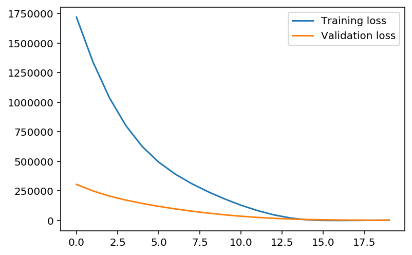

```python
plt.plot(train_losses, label='Training loss')
plt.plot(valid_losses, label='Validation loss')
plt.legend()
_ = plt.ylim()
```

```
[[  0.         55.99504    63.4369   ]
 [ 68.7865     43.96129   104.23082  ]
 [ 38.89555   140.28471    85.994736 ]
 [ 31.763384  119.47562    81.859764 ]
 [ 55.414253  142.97546    88.258385 ]
 [ 65.84148   175.95456    80.65607  ]
 [ 39.41966    81.1225     75.92284  ]
 [ 30.388746  117.90761    68.96178  ]
 [ 95.332375  103.56932   101.45951  ]
 [ 98.18262   209.50912    97.91977  ]
 [253.4849    206.39058    82.25006  ]
 [167.46454   228.50883    91.135284 ]
 [ 82.25968     0.         93.576775 ]
 [ 62.889565  177.7532     77.31209  ]
 [ 34.94313    86.44025    77.93387  ]
 [ 95.5239    121.330246  100.18526  ]
 [ 75.0401    229.517      95.7781   ]
 [141.07927   203.49463   104.91149  ]
 [ 56.62217     0.        104.68808  ]
 [ 89.07476   180.38538    92.68824  ]
 [  0.6189635   0.         53.761715 ]
 [ 20.937181   63.572006   78.56946  ]
 [ 70.37818   105.5685    107.17345  ]
 [107.30684   196.63542   116.54019  ]
 [ 51.16157    86.115906  106.54608  ]
 [ 39.110226  176.94179    87.98634  ]
 [ 32.455795   38.89386    80.69095  ]
 [  5.7871075  80.37683    66.29455  ]]
```

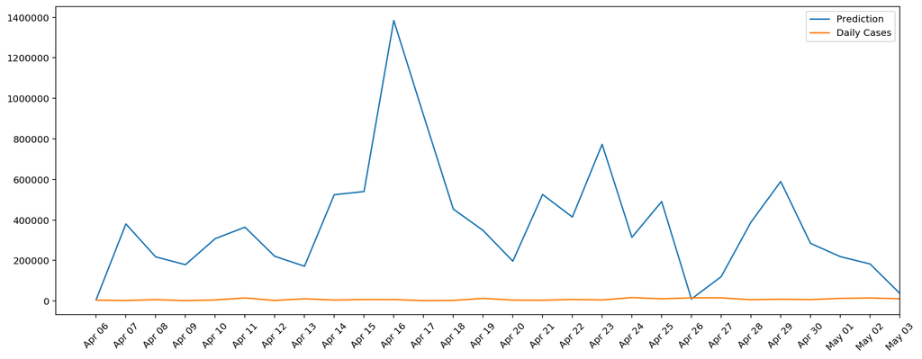

```python
with torch.no_grad():
    predict = model_mlp(featuresTest_mlp).data.numpy()
    print(predict)

fig, ax = plt.subplots(figsize=(16,6))

mean, std = scaled_features['Daily Cases']
#predictions = model_mlp.train()
predictions = predict.T*std + mean
ax.plot(predictions[0], label='Prediction')
ax.plot((test_targets['Daily Cases']*std + mean).values, label='Daily Cases')
ax.set_xlim(right=len(predictions))
ax.legend()

dates = pd.to_datetime(df_usa_merge.iloc[test_data.index]['Date'])
dates = dates.apply(lambda d: d.strftime('%b %d'))
ax.set_xticks(np.arange(len(dates)))
_ = ax.set_xticklabels(dates, rotation=45)
```

## C.1 CNN model

```python
class CNNModel(nn.Module):
    ### TODO: choose an architecture, and complete the class
    def __init__(self):
        super(CNNModel, self).__init__()
        ## Define layers of a CNN
        # convolutional layer 1
        self.conv1 = nn.Conv2d(1, 16, kernel_size=(1, 2), padding=1)
        # convolutional layer 2
        self.conv2 = nn.Conv2d(16, 32, kernel_size=(1, 2), padding=1)
        # convolutional layer 3
        self.conv3 = nn.Conv2d(32, 64, kernel_size=(1, 2), padding=1)
        # max pooling layer
        self.pool = nn.MaxPool2d(kernel_size=(1, 2))
        # linear layer
        self.fc1 = nn.Linear(64*7, 1000)
        self.fc2 = nn.Linear(1000, 500)
        self.fc3 = nn.Linear(500, 2)
        self.dropout = nn.Dropout(0.25)#0.5

        self.bn1 = nn.BatchNorm2d(16)
        self.bn2 = nn.BatchNorm2d(32)
        self.bn3 = nn.BatchNorm2d(64)

    def forward(self, x):
        ## Define forward behavior
        x = self.bn1(self.pool(F.relu(self.conv1(x))))
        x = self.bn2(self.pool(F.relu(self.conv2(x))))
        x = self.bn3(self.pool(F.relu(self.conv3(x))))
        #flatten
        x = x.view(x.size(0), -1)
        #x = self.dropout(x)
        x = F.relu(self.fc1(x))
        #x = self.dropout(x)
        x = F.relu(self.fc2(x))
        #x = self.dropout(x)
        x = self.fc3(x)
        return x
```

## C.2 data set

```python
# Create feature and targets tensor for train set.
##featuresTrain = torch.from_numpy(features_train).type(torch.FloatTensor)
##targetsTrain = torch.from_numpy(targets_train).type(torch.LongTensor)
featuresTrain = torch.Tensor(train_features_cnn.values).type(torch.FloatTensor)
targetsTrain = torch.Tensor(train_targets_cnn.values).type(torch.LongTensor)

# Create feature and targets tensor for test set.
#test_features_cnn, test_targets_cnn
featuresTest = torch.from_numpy(test_features_cnn.values).type(torch.FloatTensor)
targetsTest = torch.from_numpy(test_targets_cnn.values).type(torch.LongTensor)


batch_size = 50
train = torch.utils.data.TensorDataset(featuresTrain, targetsTrain)#(featuresTrain, targetsTrain)
train_loader = torch.utils.data.DataLoader(train,
                                            batch_size = batch_size,
                                            shuffle = False)
#print(images)
```

## C.3 Train

```python
model = CNNModel()
error = nn.CrossEntropyLoss()
learning_rate = 0.013
optimizer = torch.optim.SGD(model.parameters(), lr=learning_rate)
#optimizer = torch.optim.Adam(model.parameters(), lr=0.001)

# CNN model training
count = 0
loss_list = []
iteration_list = []
accuracy_list = []
num_epochs = 100
for epoch in range(num_epochs):
    for i, (images, labels) in enumerate(train_loader):
        model.train()
        train = images#.reshape(images.shape[0],1,1, 7)
        # Clear gradients
        optimizer.zero_grad()
        # Forward propagation
        outputs = model(train)
        # Calculate softmax and ross entropy loss
        loss = error(outputs, labels)
        # Calculating gradients
        loss.backward()
        # Update parameters
        optimizer.step()

    # Iterate through test dataset
    model.eval()
    test = featuresTest#.reshape(featuresTest.shape[0],1,1, 7)
    # Forward propagation
    outputs = model(test)
    # Get predictions from the maximum value
    _, predicted = torch.max(outputs.data, 1)
    # Total number of labels
    total = len(targetsTest)
    correct = (predicted == targetsTest).sum()
    accuracy = 100 * correct / float(total)

    # store loss and iteration
    loss_list.append(loss.item()*100)
    iteration_list.append(epoch)
    accuracy_list.append(accuracy)

    print('Iteration: {}  Loss: {}  Accuracy: {} %'.format(epoch, loss.item(), accuracy))

###############Start predictation#####################
model.eval()
test = torch.from_numpy(test_df.values).type(torch.FloatTensor)
outest = model(test.reshape(-1, 1, 1, 7))

_, predicted = torch.max(outest.data, 1)
idx = np.arange(start= 892, stop= 892 +test.shape[0])
df2 = pd.DataFrame({'Passenger': idx,
                    'Survived': predicted})
df2.to_csv('./jrxie.csv', index= False)
print ("Finish!!")
```

[output not shown]